# A Representative Sample of Australian Participant’s Attitudes Towards Government Tracking During the COVID-19 Pandemic.

Prof Simon Dennis$^1$, Dr Paul Garrett$^1$, Mr Joshua White$^1$, A/Prof Daniel Little$^1$, A/Prof Amy Perfors$^1$, Prof Yoshihisa Kashima$^1$, & Prof Stephan Lewandowsky$^2$

$^1$Complex Human Data Hub, School of Psychological Sciences, The University of Melbourne.

$^2$School of Psychological Sciences, The University of Bristol.

Updated 18 April 2020

# Background

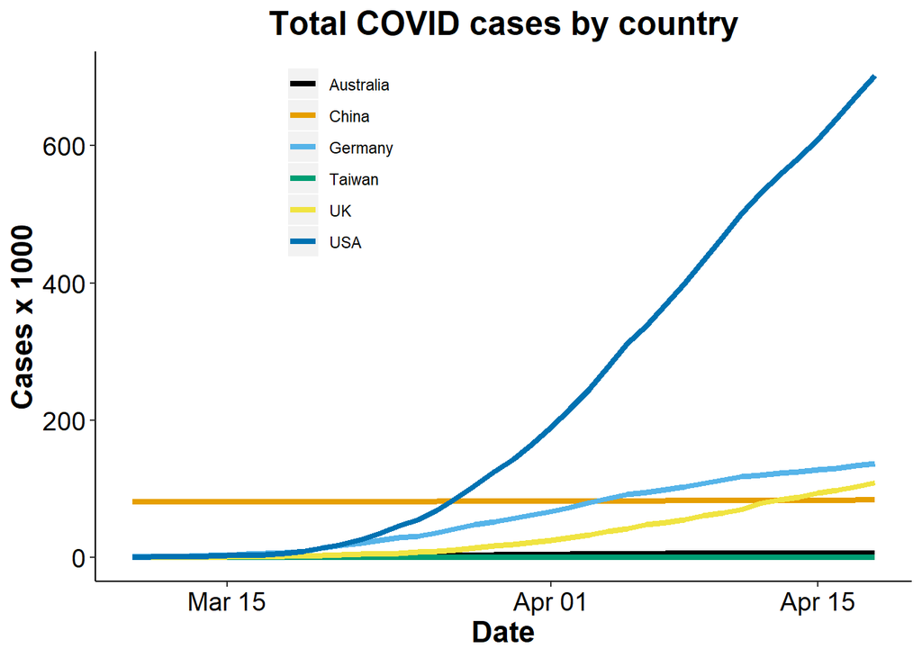

In Australia, lock down measures and physical distancing have already had an impact on the spread of COVID-19, slowing the rate of transmission and helping to “flatten the curve” - the process of slowing the exponential transmission rate of the virus. Fortunately, Australia’s intensive care units have not been overwhelmed by COVID-19 cases, ensuring that those who show signs of respiratory distress can get access to life saving interventions; but this has not been the case everywhere in the world (see below Figure).

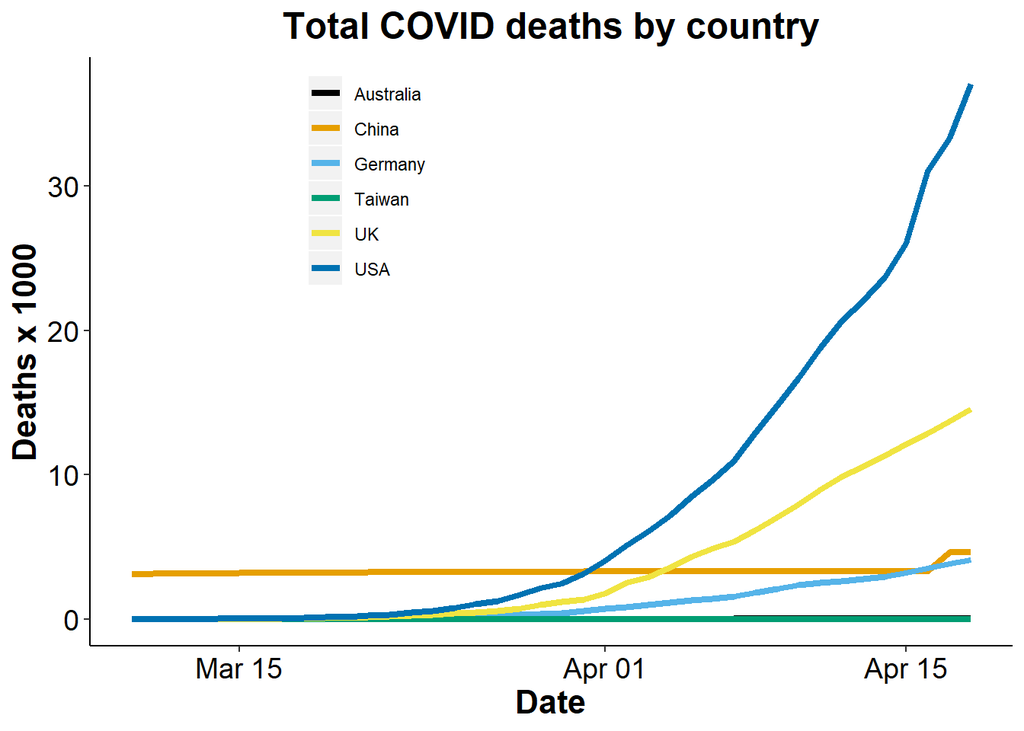

Although Australia is working hard to flatten the curve (see below Figure), it is unclear whether current government policies will be effective as non-essential individuals re-enter the workforce and face the prospect of a second outbreak of COVID-19, (e.g., Singapore). The moderate to high transmissibility of this virus has required some governments to consider moderate to extreme measures in order to prevent further transmissions. Indeed, the nature of the COVID-19 pandemic may require governments to use big data technologies to help contain its spread (Bonsall, Parker, & Fraser, 2020).

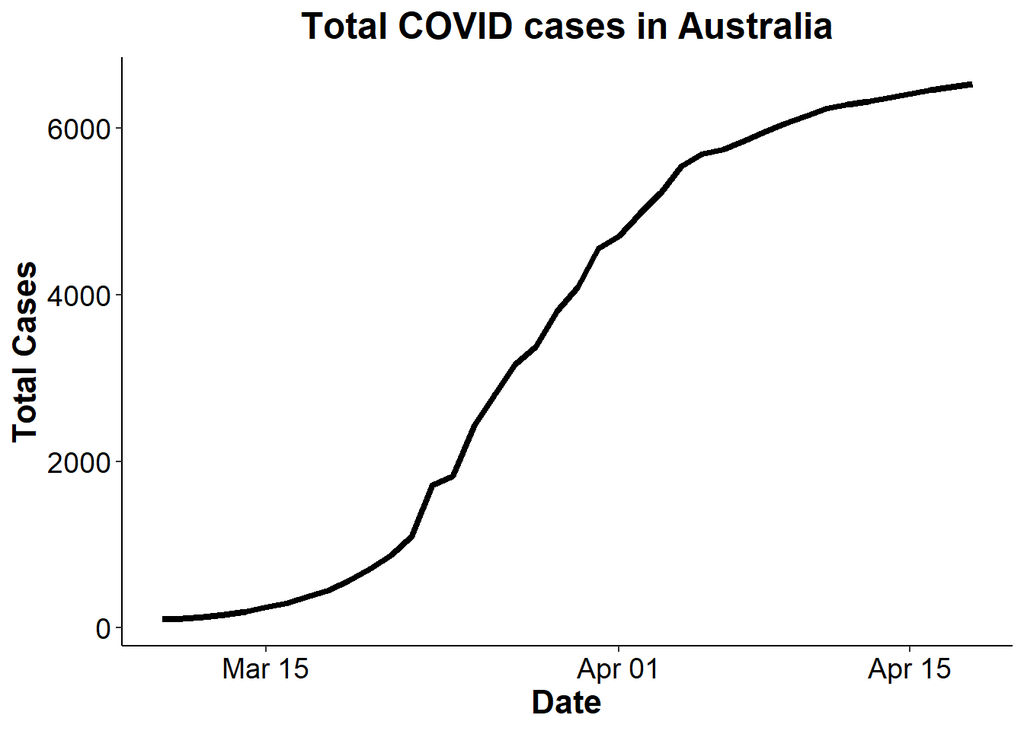

Countries that have managed to “flatten the curve”, for example, Singapore and Taiwan, have employed collocation tracking through mobile Wi-Fi, GPS, and Bluetooth as a strategy to mitigate the impact of COVID-19 (Wang et al., 2020). Through collocation tracking, government or third-party agencies may observe who you have been in contact with and when this contact occurred, allowing for the rapid implementation of appropriate measures to reduce the spread of COVID-19.

The effectiveness of collocation tracking relies on the willingness of the population to support such measures, implying that government policy-making should be informed by the likelihood of public compliance. Gaining the social license - broad community acceptance beyond formal legal requirements - for collocation tracking requires the perceived public health benefits to outweigh concerns of personal privacy, security, and any potential risk of harm.

This report forms the preliminary results of a longitudinal cross-cultural study mapping the evolution of people’s attitudes towards government tracking during the COVID-19 crisis. We aim to understand (1) the factors that influence the social license around governmental use of location tracking data in an emergency, (2) how this may change over time, and (3) how this may differ between countries.

## The Current Report

The results we present here were collected through a representative survey of Australian residents that assessed their attitudes towards Government tracking and third-party tracking - specifically the Bluetooth tracking proposed by Google and Apple - during the COVID-19 pandemic. We presented participants with one of three scenarios describing different tracking methods that may reduce the spread of COVID-19. We then question participants’ attitudes towards the proposed methods.

The two Government tracking scenarios differed in two important ways. In scenario one, participants could opt-in to being tracked by the Government and the collected data could only be used to contact those who may have been exposed to COVID-19. This scenario reflects the current policy and app proposed by the Australia Government. In scenario two, all people using a mobile phone would have their data tracked with no possibility to opt-out, and tracking data could be used to issue fines and arrests for violations of lock down orders. In the third scenario, we ask about participant’s attitudes towards downloading one of the Bluetooth tracking apps accessible through the Google or Apple app-stores. Contact tracing would be voluntary and the identity of COVID-19 positive individuals would remain anonymous.

The three scenarios are presented below:

### Scenario One - Government App

The COVID-19 pandemic has rapidly become a worldwide threat. Containing the virus’ spread is essential to minimize the impact on the healthcare system, the economy, and save many lives. The Australian Government might consider using smartphone tracking data to identify and contact those who may have been exposed to people with COVID-19. This would help reduce community spread by identifying those most at risk and allowing health services to be appropriately targeted. **Only people that downloaded a government app and agreed to be tracked and contacted would be included in the project.** The more people that download and use this app the more effectively the Government would be able to contain the spread of COVID-19. **Data would be stored in an encrypted format on a secure server accessible only to the Australian Government. Data would only be used to contact those who might have been exposed to COVID-19.**

### Scenario Two - Moblie Network Tracking

The COVID-19 pandemic has rapidly become a worldwide threat. Containing the virus’ spread is essential to minimize the impact on the healthcare system, the economy, and save many lives. The Australian Government might consider using phone tracking data supplied by telecommunication companies to identify and contact those who may have been exposed to people with COVID-19. This would help reduce community spread by identifying those most at risk and allowing health services to be appropriately targeted. **All people using a mobile phone would be included in the project, with no possibility to opt-out.** Data would be stored in an encrypted format on a secure server accessible only to **the Australian Government who may use the data to locate people who were violating lockdown orders and enforce them with fines and arrests where necessary.** Data would also be used to inform the appropriate public health response and to contact those who might have been exposed to COVID-19, and individual quarantine orders could be made on the basis of this data.

### Scenario Three - Bluetooth Tracking

The COVID-19 pandemic has rapidly become a worldwide threat. Containing the virus’ spread is essential to minimize the impact on the healthcare system, the economy, and save many lives. **Apple and Google have proposed adding a contact tracing capability to existing smartphones to help inform people if they have been exposed to others with COVID-19.** This would help reduce community spread of COVID-19 by allowing people to voluntarily self-isolate. When two people are near each other, their phones would connect via Bluetooth. If a person is later identified as being infected, the people they have been in close proximity to are then notified **without the government knowing who they are. The use of this contact tracing capability would be completely voluntary. People who are notified would not be informed who had tested positive.**

# Results

## Status of the initial data collected

These results represent a snapshot from `1590` participants collected during the second wave of the project, Establishing the social licence for Government tracking in Australia. This representative sample was gathered through the data collection platform Dynata and 500 participants were allocated to each of the three scenarios.

Notes on cleaning the data.

1. The second and third rows of the raw CSV file were deleted before analysis. These rows contained header information as part of the raw Qualtrics csv that interfered with loading the data into R.
2. Of the initial `1590` participants collected, `24` participants were removed prior to analysis for indicating a country of residence other than Australia.
3. A further `8` participants were removed prior to analysis for indicating they were below the age of 18.
4. An additional `353` participants did not pass the attention check.
5. Finally, `51` participants began and did not complete the survey.

After cleaning the data for the above participants, the final sample at analysis was `1154` participants.

# Descriptive Statistics

Gender was evenly divided between men and women. Within our sample, participants most frequently reported as having a university education (54%) or a higher school education (37%). Ages ranged from 18 years to 83 years (M = 48 years, SD = 17 years). The distribution of reported ages was roughly uniform within the age range 20–80, and under represented for ages 80+.

| Gender identification: Percentages | Gender identification: Percentages #Total |
| --- | --- |
| Gender |  |
| Men | 50.3 |
| Women | 49.3 |
| Other | 0.2 |
| Prefer not to say | 0.2 |
| #Total cases | 1154 |

| Level of education: Percentages | Level of education: Percentages #Total |
| --- | --- |
| Education |  |
| < High School | 8.8 |
| High School | 37.1 |
| University | 54.2 |
| #Total cases | 1154 |

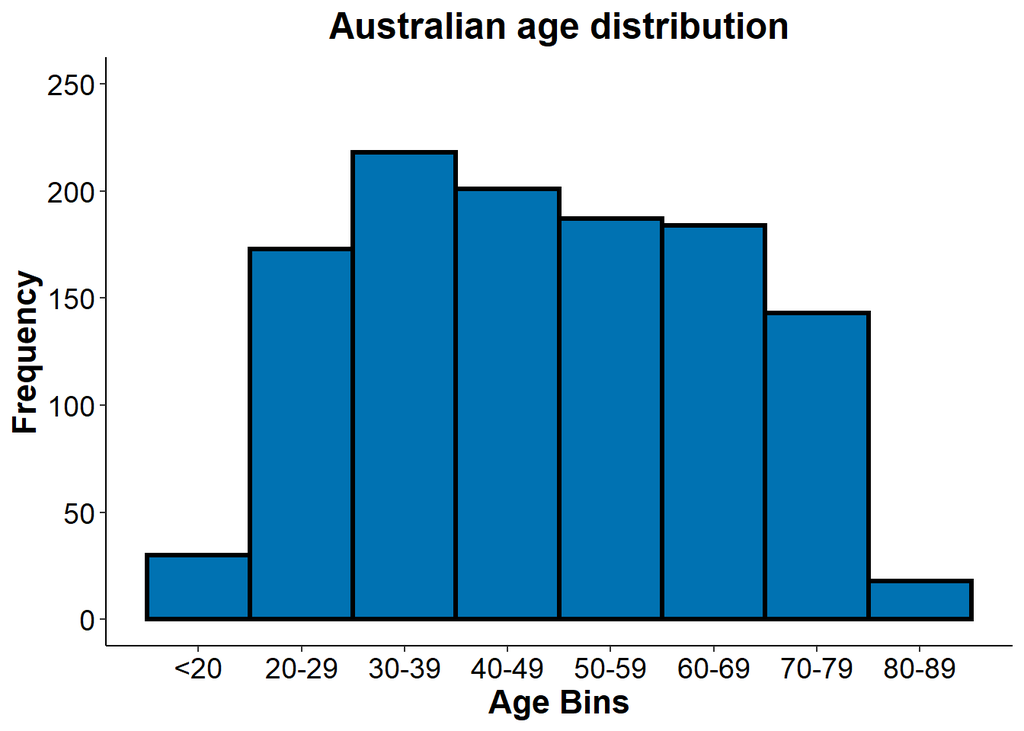

# Impacts of COVID

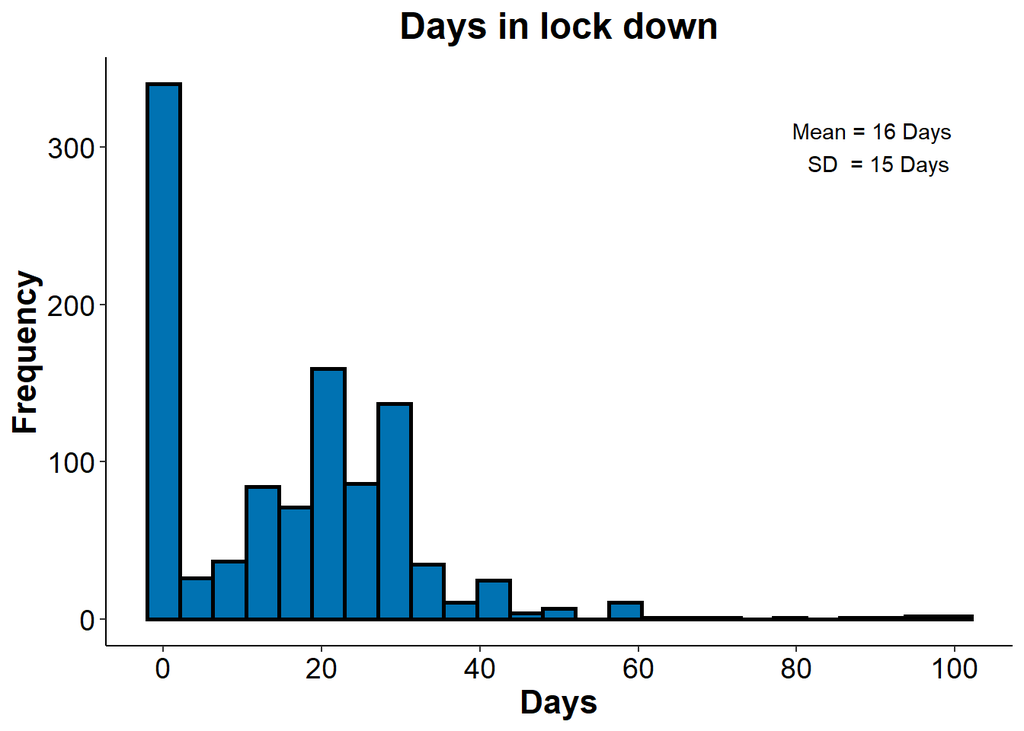

| I have lost my job: Percentages | I have lost my job: Percentages #Total |
| --- | --- |
| I lost my job |  |
| No | 81.1 |
| Yes | 18.9 |
| #Total cases | 1154 |

| Information source: Percentages | Information source: Percentages #Total |
| --- | --- |
| Information source |  |
| Newspaper (printed or online) | 18.9 |
| Social media | 13.2 |
| Friends/family | 3.1 |
| Radio | 3.8 |
| Television | 55.2 |
| Other | 4.3 |
| Do not folllow | 1.5 |
| #Total cases | 1154 |

| Somebody I know tested positive for COVID-19: Percentages | Somebody I know tested positive for COVID-19: Percentages #Total |
| --- | --- |
| Tested pos someone I know |  |
| No | 92.2 |
| Yes | 7.8 |
| #Total cases | 1154 |

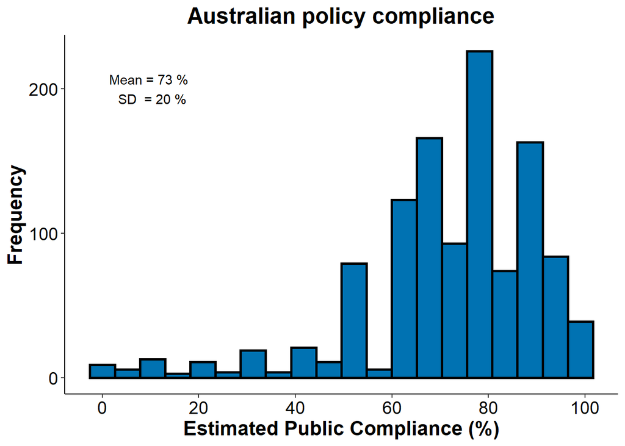

# Perceived Risk of COVID

When asked about COVID-19 within the Australian population, participants most frequently reported the virus to be moderate in severity and that the virus posed a ‘somewhat’ or ‘very’ harmful risk to their personal health. Ninety-seven percent of participants reported the virus to be at least ‘a little severe’ (2) for the population and at least ‘a little harmful’ (2) to their health.

When asked about their concern over testing positive to COVID-19, participants were normally distributed and centered on moderately concerned. When asked about their concern over someone they know testing positive to COVID-19, participants responses were negatively skewed. This indicates a bias towards concern over others in their community, such as the elderly, testing positive to COVID-19. A strong correlation was observed between concern for others and concern for self (r = .78), and between risk of personal harm and concern for self (r = .6).

Finally, we asked participants to report their estimates on the number of fatalities across a range of countries with moderate-to-high media coverage in Australia. Responses were made on a sliding scale ranging from 0 - 50,000; results are reported in estimated deaths per 1000 (see violin plot).

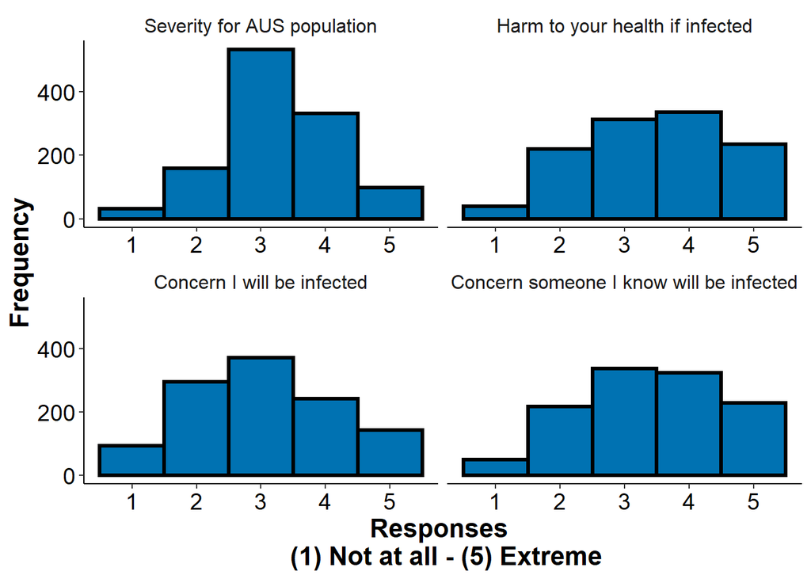

```
##                    COVID_gen_harm COVID_pers_harm COVID_pers_concern
## COVID_gen_harm              1.000           0.442              0.539
## COVID_pers_harm             0.442           1.000              0.606
## COVID_pers_concern          0.539           0.606              1.000
## COVID_concern_oth           0.532           0.468              0.779
##                    COVID_concern_oth
## COVID_gen_harm                 0.532
## COVID_pers_harm                0.468
## COVID_pers_concern             0.779
## COVID_concern_oth              1.000
```

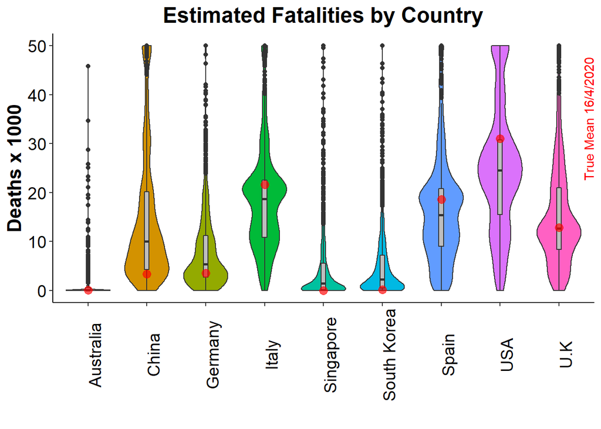

# Perceived Impact of Government Tracking

The following violin plots characterizes participant’s confidence that in each scenario Government tracking would:

1. Reduce their likelihood of contracting COVID-19
2. Allow them to resume their normal lives more rapidly
3. Reduce spread of COVID-19 in the community.

Participants in scenario two displayed the highest confidence in the tracking to reduce COVID-19 spread, and reduce their likelihood of contracting the virus. Confidence was lower and roughly equal in scenarios one and three. The likelihood that any scenario would allow participants to return to normal activities was low and roughly equal across vignettes.

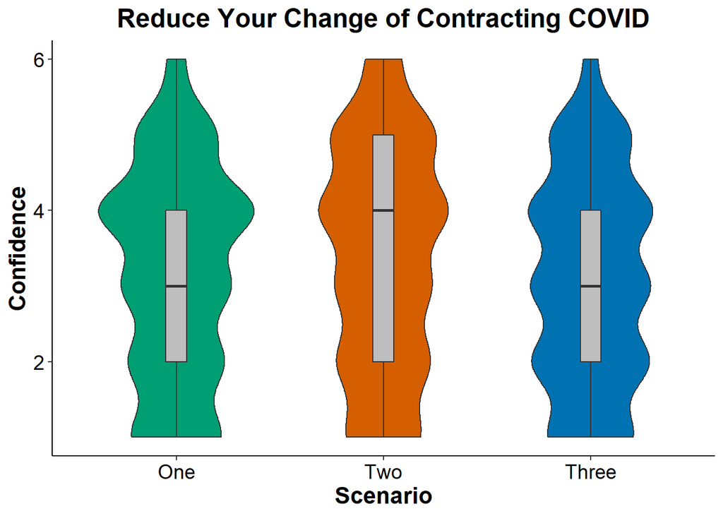

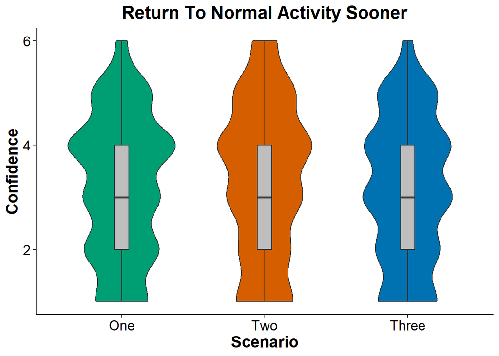

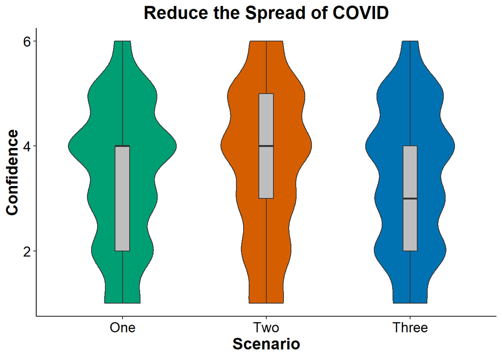

## Acceptability of Government Tracking

|  |  |  | #Total |
| --- | --- | --- | --- |
| Scenario Type |  |  |  |
| 1. Scenario One | Acceptability of policy | No | 37.2 |
|  |  | Yes | 62.8 |
|  |  | #Total cases | 387 |
| 2. Scenario Two | Acceptability of policy | No | 32.9 |
|  |  | Yes | 67.1 |
|  |  | #Total cases | 389 |
| 3. Scenario Three | Acceptability of policy | No | 36.2 |
|  |  | Yes | 63.8 |
|  |  | #Total cases | 378 |

```
##
##  Pearson's Chi-squared test
##
## data:  unlabel(accept1$value) and unlabel(accept1$key)
## X-squared = 1.7287, df = 2, p-value = 0.4213
```

The following table displays participant’s acceptability of Government tracking as probed after they have answer a series of questions about the scenario. The general trend in acceptability remains after answering questions about Government tracking, reducing slightly in scenario two and three to make acceptability comparable across scenarios one (63%), two (64%) and three (63%).

|  |  |  | #Total |
| --- | --- | --- | --- |
| Scenario Type |  |  |  |
| 1. Scenario One | Acceptability of policy | No | 37.0 |
|  |  | Yes | 63.0 |
|  |  | #Total cases | 387 |
| 2. Scenario Two | Acceptability of policy | No | 35.7 |
|  |  | Yes | 64.3 |
|  |  | #Total cases | 389 |
| 3. Scenario Three | Acceptability of policy | No | 37.0 |
|  |  | Yes | 63.0 |
|  |  | #Total cases | 378 |

```
##
##  Pearson's Chi-squared test
##
## data:  unlabel(accept2$value) and unlabel(accept2$key)
## X-squared = 0.17734, df = 2, p-value = 0.9151
```

## Conditional Acceptance of Government Tracking

The following results were collected from those people who indicated that they would not download the app (scenarios one and three) or who indicated that Government tracking was not acceptable (scenario two).

The following table describes acceptability of tracking if a sunset clause were included in the tracking policy, for example, limiting Government tracking to a period of six months after which the data would be destroyed. Of those participants who viewed scenario two, 33% of responders changed their response and deemed tracking to be acceptable under a sunset clause. In scenario one, 28% changed their attitude and deemed tracking acceptable under a sunset clause. In scenario three, 19% changed their attitude and deemed tracking acceptable under a sunset clause.

|  |  |  | #Total |
| --- | --- | --- | --- |
| Scenario Type |  |  |  |
| 1. Scenario One | Acceptability with sunset | No | 71.3 |
|  |  | Yes | 28.7 |
|  |  | #Total cases | 143 |
| 2. Scenario Two | Acceptability with sunset | No | 66.9 |
|  |  | Yes | 33.1 |
|  |  | #Total cases | 139 |
| 3. Scenario Three | Acceptability with sunset | No | 81.4 |
|  |  | Yes | 18.6 |
|  |  | #Total cases | 140 |

```
##
##  Pearson's Chi-squared test
##
## data:  unlabel(sunset$value) and unlabel(sunset$key)
## X-squared = 7.8979, df = 2, p-value = 0.01927
```

The following tables describe acceptability of Government tracking in scenario one if i) the tracking data were to stay on the phone and only be uploaded with the consent of the individual (scenario one only), and ii) if participants were able to opt-in to the data collection (scenario two only). Fourty-seven percent of responses changed from not-acceptable to acceptable in scenario one if data were stored locally on their phones. Responses changed in 60% of participants in scenario two if an opt-out clause was included.

|  | #Total |
| --- | --- |
| Acceptability with local storage |  |
| No | 53.1 |
| Yes | 46.9 |
| #Total cases | 143 |

|  | #Total |
| --- | --- |
| Acceptability with opt out |  |
| No | 39.6 |
| Yes | 60.4 |
| #Total cases | 139 |

# Public Understanding of the Proposed Tracking Methods

The next graph shows responses to the following items (abridged from survey):

1. How easy is it for people to decline participation in the proposed project?
2. To what extent is the Government only collecting the data necessary?
3. How sensitive is the data being collected in the proposed project?
4. How serious is the risk of harm that could arise from the proposed project?
5. How much do you trust the Government to use the tracking data only to deal with the COVID-19 pandemic?
6. How much do you trust the Government to be able to ensure the privacy of each individual?
7. How secure is the data that would be collected for the proposed project?
8. To what extent do people have ongoing control of their data?

The following results hold across both scenario one and scenario two. Participants generally displayed a moderate degree of Government trust and indicated that the Government was only collecting data necessary for COVID-19 tracing. Participants generally believed that the Government would ensure their privacy and secure their data. Although participants did not view the risk of harm in collecting this data as particularly high (risk was notably higher for scenario two), they did understand that the data being collected was sensitive, (i.e., in need of security and privacy).

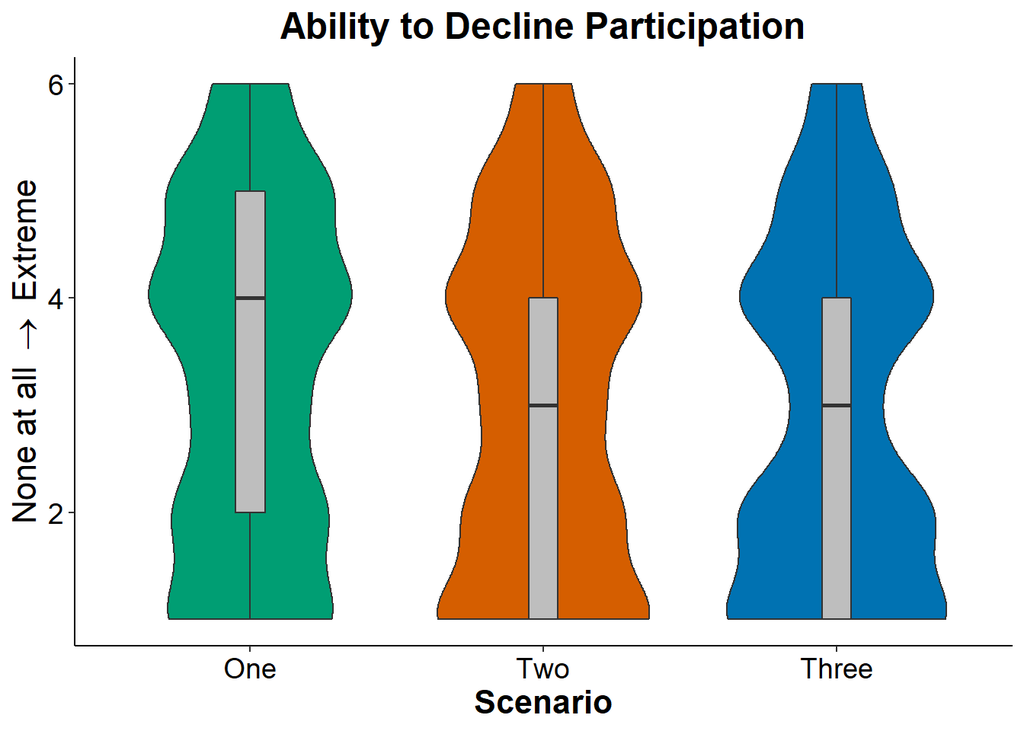

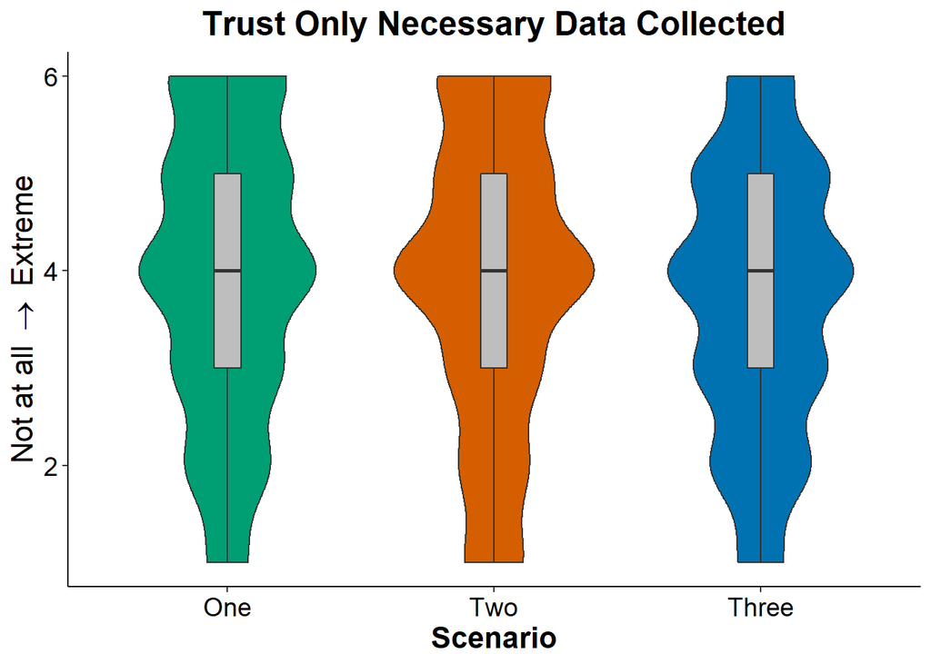

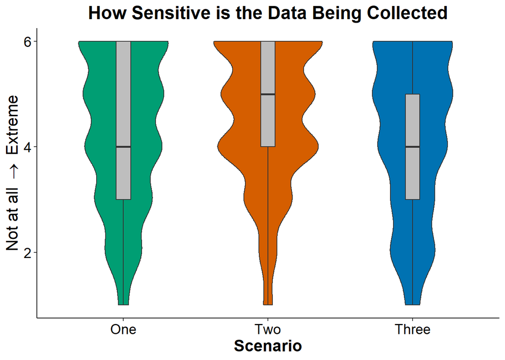

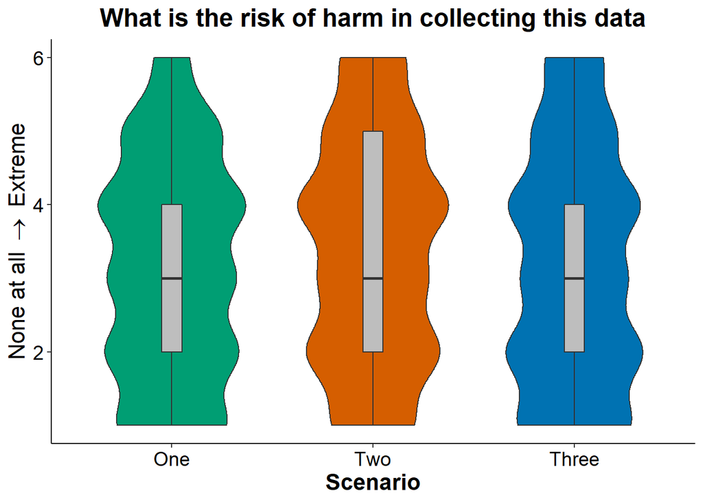

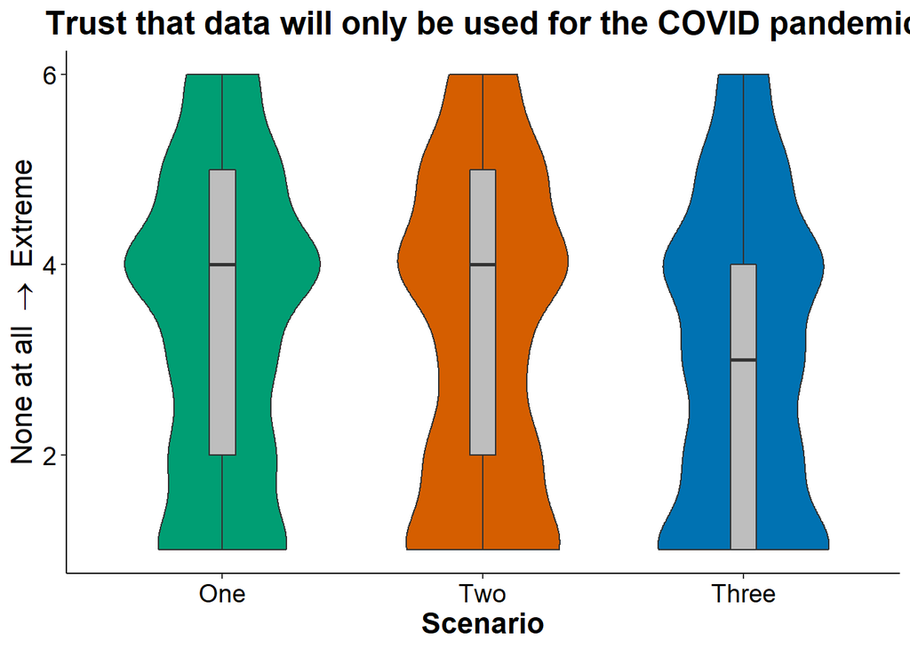

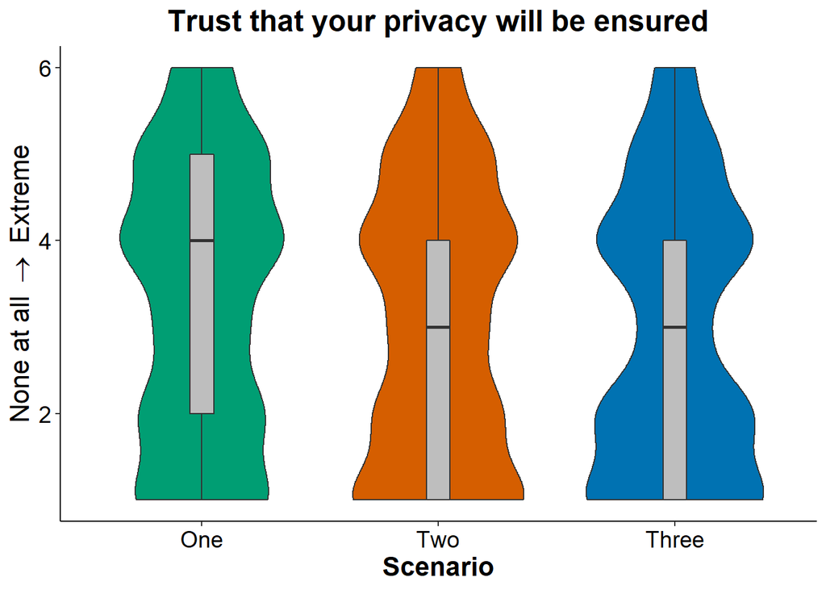

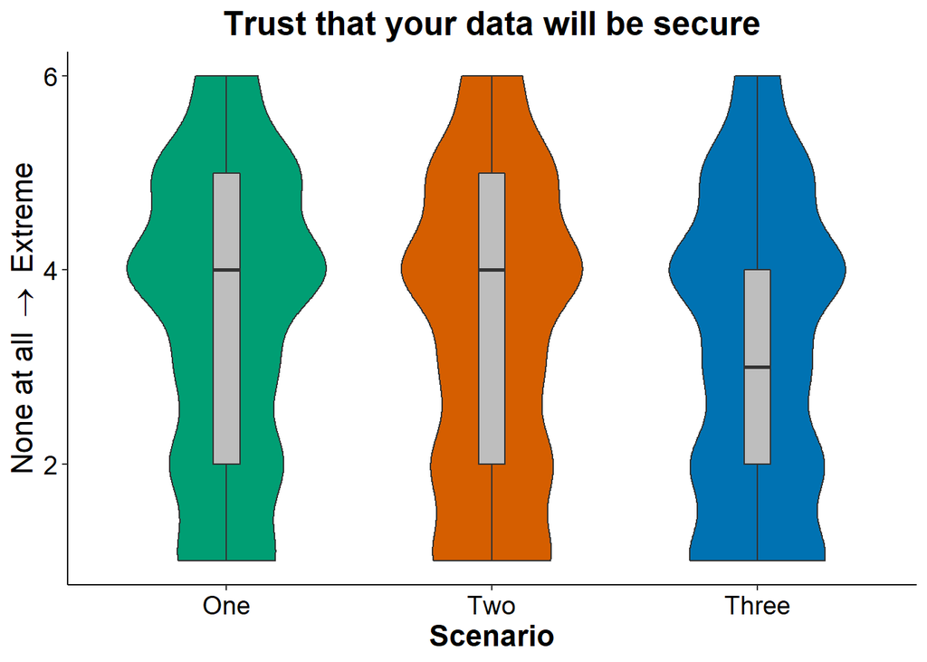

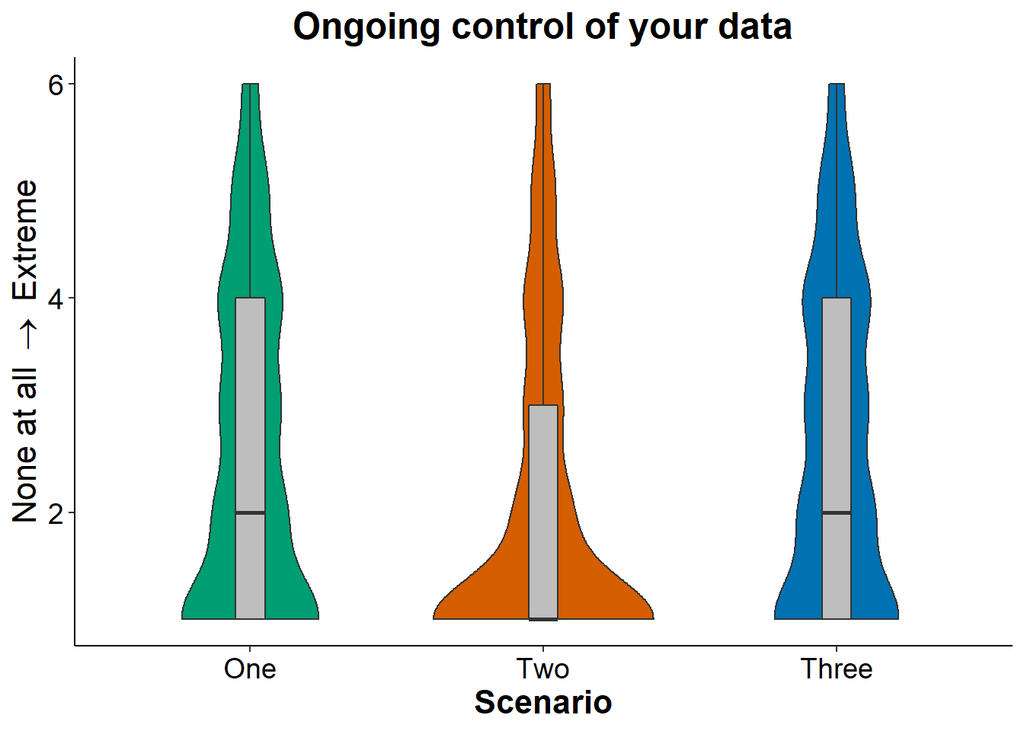

# Immunity Passports

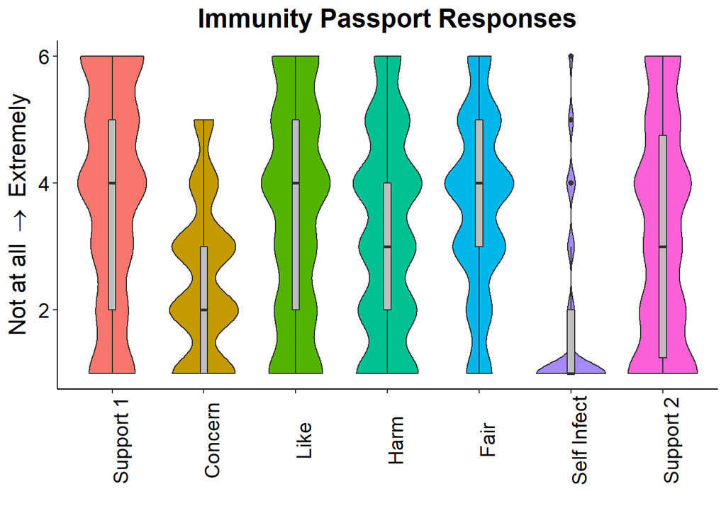

|  | #Total |
| --- | --- |
| Final support for Immunity Passports |  |
| Not at all | 25.0 |
| Slightly | 16.1 |
| A bit | 13.4 |
| Moderately | 20.4 |
| A lot | 12.3 |
| Fully | 12.7 |
| #Total cases | 1154 |

# References

Bonsall, D., Parker, M., Fraser, C. (2020).Sustainable containment of COVID-19 using smartphones in China: Scientific and ethical underpinnings for implementation of similar approaches in other settings.

The world health organization (WHO). WHO announces COVID-19 outbreak a pandemic. Retrieved from http://www.euro.who.int/en/health-topics/health-emergencies/coronavirus-covid-19/news/news/2020/3/who-announces-covid-19-outbreak-a-pandemic.

Wang, C. J., Ng, C. Y., & Brook, R. H. (2020). Response to COVID-19 in Taiwan: big data analytics, new technology, and proactive testing. JAMA.

Zhou, T., Liu, Q., Yang, Z., Liao, J., Yang, K., Bai, W., … & Zhang, W. (2020). Preliminary prediction of the basic reproduction number of the Wuhan novel coronavirus 2019-nCoV. Journal of Evidence-Based Medicine.